# Praktikum 5 Anreg

# Library

```r
library(readxl) # untuk membaca data
library(GGally) # untuk menghasilkan matriks hubungan antarpeubah
```

```r
library(corrplot) # untuk menghasilkan matriks korelasi
library(dplyr) # untuk manipulasi data
library(car) # untuk memeriksa multikolinearitas
```

# Data

```r
data <- read_excel("C:/Users/ATIKAH MAULINA/OneDrive/Documents/STK 4/ANREG/Anreg_UAS/ANREG DATA CO2.xlsx")

head(data) # menampilkan sekian data awal
```

```
## # A tibble: 6 × 7
##   Negara                Y     X1    X2    X3     X4    X5
##   <chr>             <dbl>  <dbl> <dbl> <dbl>  <dbl> <dbl>
## 1 Argentina             3  8536. 1624. 0.919  16.5  0.098
## 2 Australia            15 51983. 5159. 0.873   3.33 0.112
## 3 Austria               7 48716. 3546. 0.685 108.   0.358
## 4 Brazil                2  7074. 1379. 0.869  25.0  0.5
## 5 Brunei Darussalam    21 26834. 9176. 0.748  84.9  0
## 6 Bulgaria              5 10760. 2665. 0.733  60.3  0.211
```

```r
str(data) # menampilkan tipe data setiap peubah
```

```
## tibble [30 × 7] (S3: tbl_df/tbl/data.frame)
##  $ Negara: chr [1:30] "Argentina" "Australia" "Austria" "Brazil" ...
##  $ Y     : num [1:30] 3 15 7 2 21 5 14 8 2 5 ...
##  $ X1    : num [1:30] 8536 51983 48716 7074 26834 ...
##  $ X2    : num [1:30] 1624 5159 3546 1379 9176 ...
##  $ X3    : num [1:30] 0.919 0.873 0.685 0.869 0.748 ...
##  $ X4    : num [1:30] 16.51 3.33 108.06 24.96 84.9 ...
##  $ X5    : num [1:30] 0.098 0.112 0.358 0.5 0 0.211 0.239 0.149 0.32 0.395 ...
```

```r
summary(data) # menampilkan ringkasan data
```

```
##     Negara                Y                X1                X2
##  Length:30          Min.   : 0.150   Min.   :  829.8   Min.   : 379.6
##  Class :character   1st Qu.: 2.000   1st Qu.: 5309.2   1st Qu.: 824.5
##  Mode  :character   Median : 4.500   Median : 8811.4   Median :2098.7
##                     Mean   : 5.644   Mean   :18720.3   Mean   :2538.1
##                     3rd Qu.: 7.000   3rd Qu.:33257.2   3rd Qu.:3273.6
##                     Max.   :21.000   Max.   :60985.5   Max.   :9175.9
##        X3               X4               X5
##  Min.   :0.2163   Min.   :  3.33   Min.   :0.00000
##  1st Qu.:0.5793   1st Qu.: 49.31   1st Qu.:0.08825
##  Median :0.7168   Median :104.26   Median :0.18600
##  Mean   :0.6780   Mean   :144.72   Mean   :0.24320
##  3rd Qu.:0.8140   3rd Qu.:149.32   3rd Qu.:0.34850
##  Max.   :0.9194   Max.   :557.42   Max.   :0.90700
```

```r
dt <- select(data, -Negara)
```

# Eksplorasi data

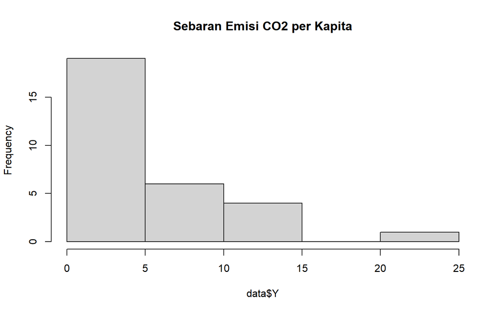

```r
hist(data$Y, main = "Sebaran Emisi CO2 per Kapita")
```

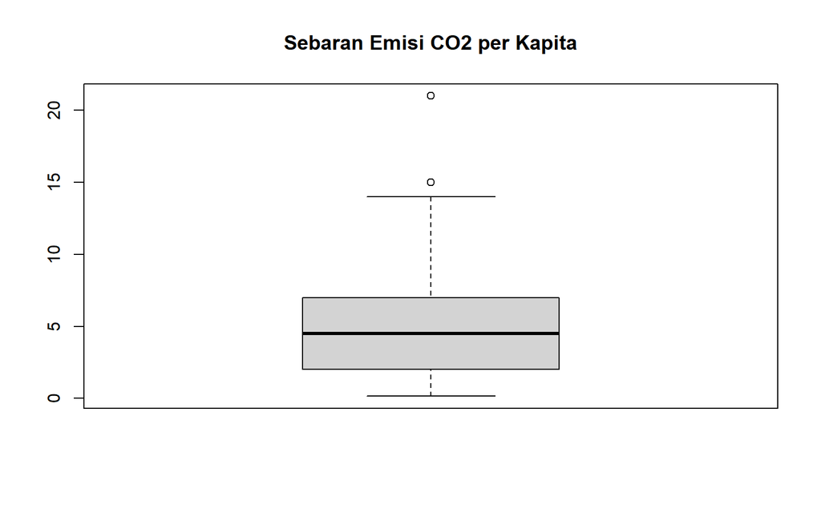

```r
boxplot(data$Y, main = "Sebaran Emisi CO2 per Kapita")
```

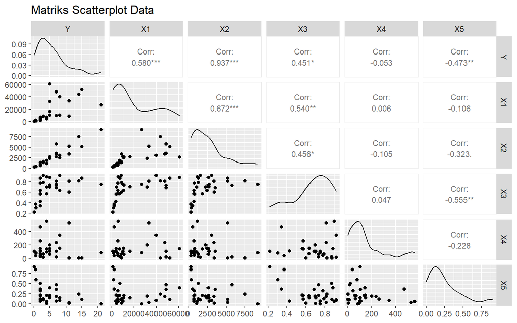

```r
ggpairs(dt,
        upper = list(continuous = wrap('cor', size = 3)),
        title = "Matriks Scatterplot Data")
```

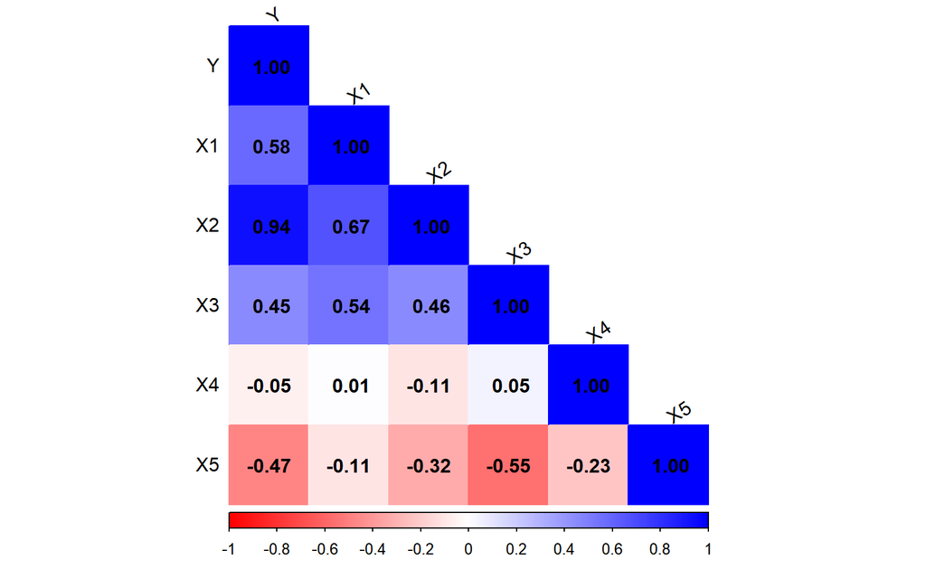

```r
cor_matrix <- cor(dt, use = "complete.obs")

corrplot(cor_matrix, method = "color", type = "lower",
         col = colorRampPalette(c("red", "white", "blue"))(200),
         addCoef.col = "black", tl.col = "black", tl.srt = 35)
```

Hasil matriks scatter plot dan korelasi menunjukkan bahwa peubah respon Emisi $CO_2$ per kapita ($Y$) memiliki hubungan positif dengan GDP per Kapita ($X1$), Rata-Rata Konsumsi Jumlah Energi per Kapita ($X2$), dan Jumlah Penduduk Daerah Perkotaan ($X3$). Sementara itu, peubah respon ($Y$) memiliki hubungan negatif dengan Kepadatan Penduduk ($X4$) dan Penggunaan Energi Alternatif ($X5$).

Selain itu, terdapat banyak korelasi tinggi antar peubah penjelas, baik lebih dari 0.5 maupun kurang dari -0.5. Beberapa di antaranya adalah: 1. GDP per Kapita ($X1$) dan Rata-Rata Konsumsi Jumlah Energi per Kapita ($X2$) memiliki korelasi positif sebesar 0.67. 2. GDP per Kapita ($X1$) dan Jumlah Penduduk Daerah Perkotaan ($X3$) memiliki korelasi positif sebesar 0.54. 3. Jumlah Penduduk Daerah Perkotaan ($X_3$) dan Penggunaan Energi Alternatif ($X_5$) menunjukkan korelasi negatif yang cukup kuat, yaitu sebesar -0.55.

Korelasi yang tinggi ini mengindikasikan adanya potensi multikolinearitas, yang dapat mempengaruhi keakuratan model yang akan dibentuk.

# Pemodelan

## Tanpa Fungsi

Perhitungan nilai $\hat{\beta}$ secara matriks dapat dilakukan dengan rumus berikut.

$$\hat{\beta} = (X'X)^{-1}
X'y$$

```r
# pembentukan matriks
n <- nrow(dt)
x0 <- rep(1,n)
x <- data.frame(x0, dt$X1, dt$X2, dt$X3,
                dt$X4, dt$X5)
x <- as.matrix(x)
y <- dt$Y
```

```r
beta_duga <- solve(t(x)%*%x)%*%t(x)%*%y
beta_duga
```

```
##                [,1]
## x0     3.218290e+00
## dt.X1 -2.027952e-06
## dt.X2  2.010760e-03
## dt.X3 -2.130811e+00
## dt.X4 -1.785334e-04
## dt.X5 -4.806704e+00
```

Hasil tersebut menjelaskan bahwa persamaan yang terbentuk adalah
$$\hat{PPM}= 3.218290 −0.000002028 X1 +
0.0020108 X2 -2.130811 X3 −0.0001785 X4 −4.806704 X5$$
Selang kepercayaan dan pengujian signifikansi setiap parameter dapat dilakukan dengan menghitung keragaman tiap dugaan parameter. Secara umum, nilai ragam dugaan parameter $\hat{\beta}_j$ dapat dihitung melalui rumus berikut.

$$Var(\hat{\beta}_j) = \hat{\sigma}^2
C_{jj}$$
Dengan matriks $C$ adalah matriks $(X'X)^{-1}$

```r
c <- data.frame(solve(t(x)%*%x))
```

Unsur diagonal dari matriks $C$ dapat digunakan untuk menghitung nilai galat baku dari setiap dugaan parameter. Galat baku ini dapat digunakan untuk menghitung selang kepercayaan dari dugaan yang dihasilkan.

$$SE(\hat{\beta}_j) =
\sqrt{Var(\hat{\beta}_j)} = \sqrt{\sigma^2 C_{jj}} =
\hat{\sigma}\sqrt{c_{ii}}$$

```r
y_hat <- x %*% beta_duga
residuals <- y - y_hat
n <- nrow(x)
p <- ncol(x)
KTG <- sum(residuals^2) / (n - p)

c22 <- c[2,2]

(se.b2 <- sqrt(KTG*c22))
```

```
## [1] 2.429531e-05
```

```r
alfa <- 0.05

#Batas Bawah beta2
(bb.b2 <- beta_duga[3,1] - abs(qt(alfa/2, df=n-p))*se.b2)
```

```
##       dt.X2
## 0.001960617
```

```r
#Batas Atas beta2
(ba.b2 <- beta_duga[3,1] + abs(qt(alfa/2, df=n-p))*se.b2)
```

```
##       dt.X2
## 0.002060903
```

# Dengan Fungsi

```r
model1 <- lm(formula = Y ~ ., data = dt)
summary(model1)
```

```
##
## Call:
## lm(formula = Y ~ ., data = dt)
##
## Residuals:
##     Min      1Q  Median      3Q     Max
## -3.8255 -0.7250  0.0006  0.5456  3.9120
##
## Coefficients:
##               Estimate Std. Error t value Pr(>|t|)
## (Intercept)  3.218e+00  1.798e+00   1.790   0.0860 .
## X1          -2.028e-06  2.430e-05  -0.083   0.9342
## X2           2.011e-03  1.969e-04  10.214 3.25e-10 ***
## X3          -2.131e+00  2.242e+00  -0.951   0.3513
## X4          -1.785e-04  2.029e-03  -0.088   0.9306
## X5          -4.807e+00  1.735e+00  -2.771   0.0106 *
## ---
## Signif. codes:  0 '***' 0.001 '**' 0.01 '*' 0.05 '.' 0.1 ' ' 1
##
## Residual standard error: 1.536 on 24 degrees of freedom
## Multiple R-squared:  0.9151, Adjusted R-squared:  0.8974
## F-statistic: 51.72 on 5 and 24 DF,  p-value: 4.513e-12
```

Dugaan parameter model secara matriks dan fungsi menghasilkan angka yang sama, sehingga perhitungan matriks dapat dikatakan sudah tepat. Pada ringkasan model ini dapat dilihat bahwa beberapa parameter yang signifikan pada taraf nyata 5%, yaitu variabel $X2$ (p-value = 3.25e-10) dan $X5$ (p-value = 0.0106). Sementara itu, variabel $X1$, $X3$, dan $X4$ tidak signifikan karena memiliki nilai p-value > 0.05. Namun secara simultan model ini signifikan dengan nilai p-value sebesar 4.513e-12, yang lebih kecil dari $α$ = 0.05. Hal ini mengindikasi model yang buruk, kemungkinan terjadi pelanggaran asumsi sisaan maupun multikolinearitas.

# Pemeriksaan Multikoliniearitas

```r
vif(model1)
```

```
##       X1       X2       X3       X4       X5
## 2.598424 2.224830 2.232688 1.142739 1.935126
```

# Uji Hipotesis Kesamaan Parameter Regresi

```r
model4 <- lm(Y ~ X2 + X3 + X4 + X5, data = dt)
summary(model4)
```

```
##
## Call:
## lm(formula = Y ~ X2 + X3 + X4 + X5, data = dt)
##
## Residuals:
##     Min      1Q  Median      3Q     Max
## -3.8375 -0.7197 -0.0210  0.5652  3.8777
##
## Coefficients:
##               Estimate Std. Error t value Pr(>|t|)
## (Intercept)  3.2922110  1.5329323   2.148  0.04163 *
## X2           0.0020002  0.0001482  13.501 5.51e-13 ***
## X3          -2.2264553  1.8881093  -1.179  0.24942
## X4          -0.0002123  0.0019482  -0.109  0.91409
## X5          -4.8701763  1.5280588  -3.187  0.00383 **
## ---
## Signif. codes:  0 '***' 0.001 '**' 0.01 '*' 0.05 '.' 0.1 ' ' 1
##
## Residual standard error: 1.505 on 25 degrees of freedom
## Multiple R-squared:  0.9151, Adjusted R-squared:  0.9015
## F-statistic: 67.33 on 4 and 25 DF,  p-value: 5.116e-13
```

```r
vif(model4)
```

```
##       X2       X3       X4       X5
## 1.312072 1.649365 1.097243 1.563355
```

Regresi yang dihasilkan tidak mengalami masalah multikolinearitas. Hasil tersebut menunjukkan bahwa peubah $X2$ dan $X5$ signifikan pada taraf nyata 5%, sedangkan $X3$ dan $X4$ tidak signifikan. Berikut adalah persamaan yang terbentuk

$$\hat{Y}= 3.2922110 + 0.0020002 X2
−2.2264553 X3 −0.0002123 X4 −4.8701763 X5$$

Hipotesis yang diuji adalah

$$Y= β_0 + β_1' (X2+X5) +
ε$$

```r
# Buat peubah baru
dt$X_new <- dt$X2 + dt$X5

# Model penuh (Full Model)
model_full <- lm(Y ~ X2 + X5, data = dt)

# Model terbatas (Restricted Model)
model_restricted <- lm(Y ~ X_new, data = dt)

# Bandingkan dengan Uji F
anova(model_restricted, model_full)
```

```
## Analysis of Variance Table
##
## Model 1: Y ~ X_new
## Model 2: Y ~ X2 + X5
##   Res.Df    RSS Df Sum of Sq      F   Pr(>F)
## 1     28 81.446
## 2     27 59.818  1    21.628 9.7625 0.004225 **
## ---
## Signif. codes:  0 '***' 0.001 '**' 0.01 '*' 0.05 '.' 0.1 ' ' 1
```

Hasil perbandingan menunjukkan bahwa p-value kurang dari $α$ = 0.05, sehingga dapat disimpulkan bahwa tolak $H_0$, artinya peubah $X2$ dan $X5$ berbeda secara signifikan sehingga tidak dapat digabung. Selanjutnya dapat dipilih apakah akan menggunakan peubah dengan 4 peubah atau hanya 2 peubah berdasarkan indikator Adjusted R-Squared, AIC, dan BIC.

```r
model_all <- lm(Y ~ X2 + X3 + X4 + X5, data = dt)
summary(model_all)
```

```
##
## Call:
## lm(formula = Y ~ X2 + X3 + X4 + X5, data = dt)
##
## Residuals:
##     Min      1Q  Median      3Q     Max
## -3.8375 -0.7197 -0.0210  0.5652  3.8777
##
## Coefficients:
##               Estimate Std. Error t value Pr(>|t|)
## (Intercept)  3.2922110  1.5329323   2.148  0.04163 *
## X2           0.0020002  0.0001482  13.501 5.51e-13 ***
## X3          -2.2264553  1.8881093  -1.179  0.24942
## X4          -0.0002123  0.0019482  -0.109  0.91409
## X5          -4.8701763  1.5280588  -3.187  0.00383 **
## ---
## Signif. codes:  0 '***' 0.001 '**' 0.01 '*' 0.05 '.' 0.1 ' ' 1
##
## Residual standard error: 1.505 on 25 degrees of freedom
## Multiple R-squared:  0.9151, Adjusted R-squared:  0.9015
## F-statistic: 67.33 on 4 and 25 DF,  p-value: 5.116e-13
```

```r
model_signif <- lm(Y ~ X2 + X5, data = dt)
summary(model_signif)
```

```
##
## Call:
## lm(formula = Y ~ X2 + X5, data = dt)
##
## Residuals:
##     Min      1Q  Median      3Q     Max
## -3.9471 -0.7260 -0.3002  0.5191  3.7407
##
## Coefficients:
##               Estimate Std. Error t value Pr(>|t|)
## (Intercept)  1.6832552  0.5972248   2.818  0.00892 **
## X2           0.0019427  0.0001351  14.377 3.58e-14 ***
## X5          -3.9872313  1.2767846  -3.123  0.00424 **
## ---
## Signif. codes:  0 '***' 0.001 '**' 0.01 '*' 0.05 '.' 0.1 ' ' 1
##
## Residual standard error: 1.488 on 27 degrees of freedom
## Multiple R-squared:  0.9103, Adjusted R-squared:  0.9037
## F-statistic:   137 on 2 and 27 DF,  p-value: 7.274e-15
```

```r
perbandingan <- data.frame(
  Model = c("Peubah Penuh", "Peubah Signifikan"),
  Adjusted_R2 = as.numeric(c(summary(model_all)$adj.r.squared, summary(model_signif)$adj.r.squared)),
  AIC = as.numeric(c(AIC(model_all), AIC(model_signif))),
  BIC = as.numeric(c(BIC(model_all), BIC(model_signif)))
)
perbandingan
```

```
##               Model Adjusted_R2      AIC      BIC
## 1      Peubah Penuh   0.9014644 116.2100 124.6171
## 2 Peubah Signifikan   0.9036705 113.8395 119.4443
```

Berdasarkan indikator Adjusted R square, AIC, dan BIC maka model dengan hanya dua peubah ($X2$ dan $X5$) dipilih sebagai model yang terbaik. Persamaan yang terbentuk adalah sebagai berikut

$$\hat{Y}= 1.6833 + 0.0019427 X2 −3.9872
X5$$
Interpretasi: 1.Dugaan nilai rata-rata $Y$ ketika $X2$ dan $X5$ bernilai 0 adalah 1.6833. 2.Dugaan nilai $Y$ akan meningkat sebesar 0.0019427 apabila $X2$ naik satu satuan dengan asumsi $X5$ konstan. 3.Dugaan nilai $Y$ akan menurun sebesar 3.9872 apabila $X5$ naik satu satuan dengan asumsi $X2$ konstan.